# HW4

Zirui Zhang

2023-04-05

```r
library(readr)
library(tidyverse)
library(dplyr)
library(genetics)
library(knitr)
library(scales)
library(ggplot2)
```

### QUESTION (1)

```r
fms = read.csv("./FMS_data.csv")
attach(fms)
```

```r
# set up traits
Trait.1 = as.numeric(DBP>80)
Trait.2 = Mean_BP
# set up genes and corresponding columns
NamesAkt1Snps = names(fms)[substr(names(fms),1,4)=="akt1"]
fmsAkt1 = fms[,is.element(names(fms),NamesAkt1Snps)]
NamesRanklSnps = names(fms)[substr(names(fms),1,5)=="rankl"]
fmsRankl = fms[,is.element(names(fms),NamesRanklSnps)]
NamesResistinSnps = names(fms)[substr(names(fms),1,8)=="resistin"]
fmsResistin = fms[,is.element(names(fms),NamesResistinSnps)]
```

### QUESTION (2)

#### (a) Association Analysis:

The pvalues for Trait 1 are stored in df1:

```r
# write a function to record p-values of chi-sq test
Trait1.Function = function(Geno){

  ObsTab = table(Trait.1,Geno)
  return(chisq.test(ObsTab)$p.value)

}
# test of the three genes:
pv.akt1.1 = apply(fmsAkt1,2,Trait1.Function)
pv.rankl.1 = apply(fmsRankl,2,Trait1.Function)
pv.resis.1 = apply(fmsResistin,2,Trait1.Function)
trait1 = c(pv.akt1.1, pv.rankl.1, pv.resis.1)
df1 = data.frame(names = names(trait1), values = trait1)
```

```r
# write a function to record p-values of chi-sq test
Trait2.Function = function(Geno){

  ObsTab = table(Trait.2,Geno) %>% na.omit()
  return(chisq.test(ObsTab)$p.value)

}
# test of the three genes:
pv.akt1.2 = apply(fmsAkt1,2,Trait2.Function)
pv.rankl.2 = apply(fmsRankl,2,Trait2.Function)
pv.resis.2 = apply(fmsResistin,2,Trait2.Function)
trait2 = c(pv.akt1.2, pv.rankl.2, pv.resis.2)
df3 = data.frame(names = names(trait2), values = trait2)
```

#### (b) Multiple Comparisons Adjustment:

##### Trait 1:

```r
# adjusted p-value for trait 1:
pv.akt1.1.adj = p.adjust(pv.akt1.1, method="BH")
pv.rankl.1.adj = p.adjust(pv.rankl.1, method="BH")
pv.resis.1.adj = p.adjust(pv.resis.1, method="BH")
trait1.ad = c(pv.akt1.1.adj, pv.rankl.1.adj, pv.resis.1.adj)
df2 = data.frame(names = names(trait1.ad), values = trait1.ad)
# kable for trait 1:
trait.1 =
  merge(df1, df2, by = "names", all.x = TRUE) %>%
  rename(SNP=names, p.value=values.x, ad.p.value=values.y)
trait.1$Gene <- c(rep("akt", 24), rep("rankl", 4), rep("resistin", 6))
trait.1 %>%
  relocate(Gene) %>%
  kable()
```

| Gene | SNP | p.value | ad.p.value |
| --- | --- | --- | --- |
| akt | akt1_a15756t | 0.7662779 | 1.0000000 |
| akt | akt1_a22889g | 0.9118820 | 1.0000000 |
| akt | akt1_a7699g | 0.6125758 | 1.0000000 |
| akt | akt1_c10744t_c12886t | 0.1339688 | 1.0000000 |
| akt | akt1_c15676t | 0.5484681 | 1.0000000 |
| akt | akt1_c5854t_c7996t | 0.8451164 | 1.0000000 |
| akt | akt1_c6024t_c8166t | 0.6581198 | 1.0000000 |
| akt | akt1_c6148t_c8290t | 0.5466755 | 1.0000000 |
| akt | akt1_c832g_c3359g | 0.6120618 | 1.0000000 |
| akt | akt1_c9756a_c11898t | 0.8718205 | 1.0000000 |
| akt | akt1_g14803t | 0.9214736 | 1.0000000 |
| akt | akt1_g15129a | 0.9642648 | 1.0000000 |
| akt | akt1_g1780a_g363a | 1.0000000 | 1.0000000 |
| akt | akt1_g20703a | 0.0396520 | 0.9516483 |
| akt | akt1_g22187a | 0.1751319 | 1.0000000 |
| akt | akt1_g23477a | 0.2231705 | 1.0000000 |
| akt | akt1_g2347t_g205t | 0.7337353 | 1.0000000 |
| akt | akt1_g2375a_g233a | 0.8493656 | 1.0000000 |
| akt | akt1_g288c | 0.7693805 | 1.0000000 |
| akt | akt1_g4362c | 0.8665157 | 1.0000000 |
| akt | akt1_t10598a_t12740a | 0.9606470 | 1.0000000 |
| akt | akt1_t10726c_t12868c | 0.6001960 | 1.0000000 |
| akt | akt1_t22932c | 0.6354618 | 1.0000000 |
| akt | akt1_t8407g | 0.5925857 | 1.0000000 |
| rankl | rankl_17458177 | 0.2963562 | 0.5927125 |
| rankl | rankl_17536280 | 0.0569337 | 0.2277346 |
| rankl | rankl_17639305 | 0.7926808 | 0.7926808 |
| rankl | rankl_4531631 | 0.7794136 | 0.7926808 |
| resistin | resistin_a537c | 0.6867151 | 0.9426650 |
| resistin | resistin_c180g | 0.9426650 | 0.9426650 |
| resistin | resistin_c30t | 0.0788187 | 0.4729124 |
| resistin | resistin_c398t | 0.9288919 | 0.9426650 |
| resistin | resistin_c980g | 0.6647105 | 0.9426650 |
| resistin | resistin_g540a | 0.8734434 | 0.9426650 |

##### Trait 2:

```r
# adjusted p-value for trait 2:
pv.akt1.2.adj = p.adjust(pv.akt1.2, method="BH")
pv.rankl.2.adj = p.adjust(pv.rankl.2, method="BH")
pv.resis.2.adj = p.adjust(pv.resis.2, method="BH")
trait2.ad = c(pv.akt1.2.adj, pv.rankl.2.adj, pv.resis.2.adj)
df4 = data.frame(names = names(trait2.ad), values = trait2.ad)
# kable for trait 1:
trait.2 =
  merge(df3, df4, by = "names", all.x = TRUE) %>%
  rename(SNP=names, p.value=values.x, ad.p.value=values.y)
trait.2$Gene <- c(rep("akt", 24), rep("rankl", 4), rep("resistin", 6))
trait.2 %>%
  relocate(Gene) %>%
  kable()
```

| Gene | SNP | p.value | ad.p.value |
| --- | --- | --- | --- |
| akt | akt1_a15756t | NaN | NaN |
| akt | akt1_a22889g | NaN | NaN |
| akt | akt1_a7699g | 0.9783252 | 0.9976009 |
| akt | akt1_c10744t_c12886t | 0.8446990 | 0.9976009 |
| akt | akt1_c15676t | NaN | NaN |
| akt | akt1_c5854t_c7996t | NaN | NaN |
| akt | akt1_c6024t_c8166t | 0.0827221 | 0.2688469 |
| akt | akt1_c6148t_c8290t | NaN | NaN |
| akt | akt1_c832g_c3359g | NaN | NaN |
| akt | akt1_c9756a_c11898t | 0.0640719 | 0.2688469 |
| akt | akt1_g14803t | NaN | NaN |
| akt | akt1_g15129a | 0.5913630 | 0.9976009 |
| akt | akt1_g1780a_g363a | NaN | NaN |
| akt | akt1_g20703a | NaN | NaN |
| akt | akt1_g22187a | 0.0709007 | 0.2688469 |
| akt | akt1_g23477a | NaN | NaN |
| akt | akt1_g2347t_g205t | 0.0572764 | 0.2688469 |
| akt | akt1_g2375a_g233a | 0.9976009 | 0.9976009 |
| akt | akt1_g288c | NaN | NaN |
| akt | akt1_g4362c | 0.9316533 | 0.9976009 |
| akt | akt1_t10598a_t12740a | 0.6479857 | 0.9976009 |
| akt | akt1_t10726c_t12868c | 0.9532788 | 0.9976009 |
| akt | akt1_t22932c | 0.8724070 | 0.9976009 |
| akt | akt1_t8407g | 0.7099138 | 0.9976009 |
| rankl | rankl_17458177 | NaN | NaN |
| rankl | rankl_17536280 | NaN | NaN |
| rankl | rankl_17639305 | NaN | NaN |
| rankl | rankl_4531631 | NaN | NaN |
| resistin | resistin_a537c | NaN | NaN |
| resistin | resistin_c180g | NaN | NaN |
| resistin | resistin_c30t | NaN | NaN |
| resistin | resistin_c398t | NaN | NaN |
| resistin | resistin_c980g | NaN | NaN |
| resistin | resistin_g540a | NaN | NaN |

#### (c) Population Stratification using PCA:

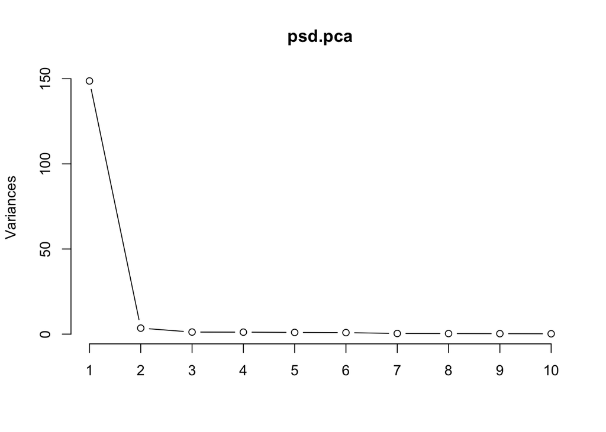

```r
# mutate all snps data into numeric, drop infinite and null values
psd = cbind(fmsAkt1, fmsRankl, fmsResistin) %>%
  as.data.frame() %>%
  mutate_if(is.character, as.factor) %>%
  mutate_if(is.factor, as.numeric) %>%
  na.omit()
# pca using prcomp
psd.pca = prcomp(psd, center=FALSE, scale=FALSE)
screeplot(psd.pca, type="lines")
```

Here the sreeplot indicates that 2 principle components should be enough, to gain a better view, we plotted PC1 vs PC2, PC1 vs PC3 and PC2 vs PC3.

```r
scores = psd.pca$x
lamda = percent(psd.pca$sdev^2/sum(psd.pca$sdev^2))
lamda
```

```
##  [1] "93.47181%" "2.21415%"  "0.76310%"  "0.72506%"  "0.62729%"  "0.56095%"
##  [7] "0.23995%"  "0.20856%"  "0.17355%"  "0.13649%"  "0.11794%"  "0.11083%"
## [13] "0.09500%"  "0.08413%"  "0.07224%"  "0.06227%"  "0.05386%"  "0.04298%"
## [19] "0.04048%"  "0.03845%"  "0.02621%"  "0.02549%"  "0.01993%"  "0.01596%"
## [25] "0.01382%"  "0.01284%"  "0.01165%"  "0.00975%"  "0.00808%"  "0.00616%"
## [31] "0.00436%"  "0.00333%"  "0.00253%"  "0.00082%"
```

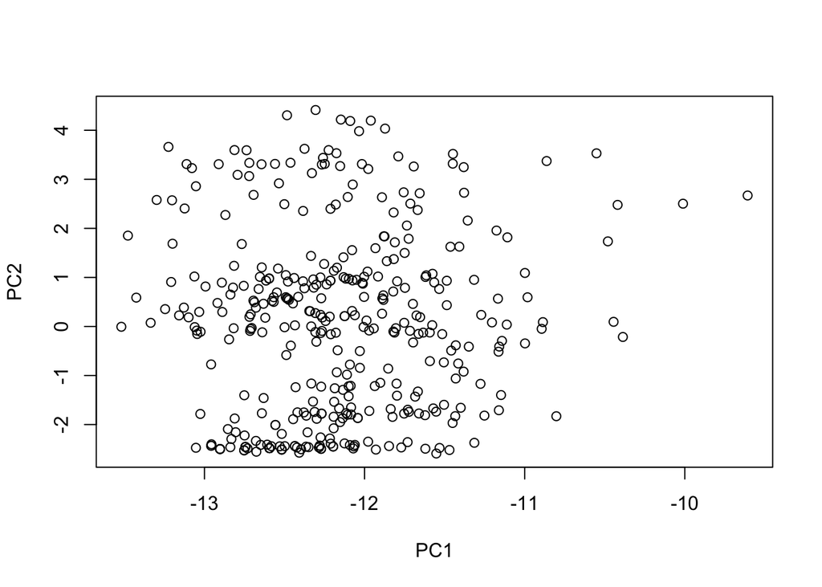

```r
plot(psd.pca$"x"[, 1], psd.pca$"x"[, 2], xlab = "PC1", ylab = "PC2")
```

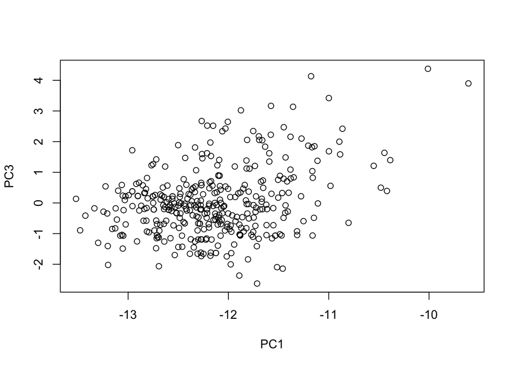

```r
plot(psd.pca$"x"[, 1], psd.pca$"x"[, 3], xlab = "PC1", ylab = "PC3")
```

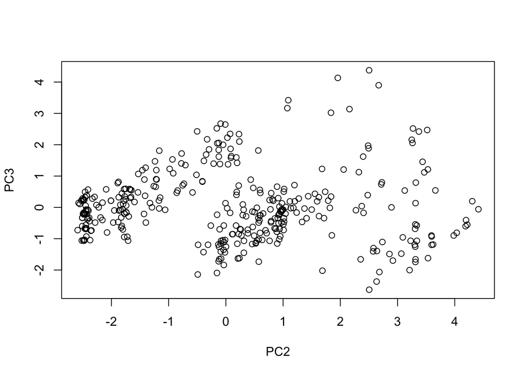

```r
plot(psd.pca$"x"[, 2], psd.pca$"x"[, 3], xlab = "PC2", ylab = "PC3")
```

#### (d) Summary:

##### 1. Descriptive Statistics For Trait1: Whether DBP>80 or not

```r
skimr::skim(Trait.1)
```

Data summary

| Name | Trait.1 |
| --- | --- |
| Number of rows | 1397 |
| Number of columns | 1 |
| _______________________ |  |
| Column type frequency: |  |
| numeric | 1 |
| ________________________ |  |
| Group variables | None |

**Variable type: numeric**

| skim_variable | n_missing | complete_rate | mean | sd | p0 | p25 | p50 | p75 | p100 | hist |
| --- | --- | --- | --- | --- | --- | --- | --- | --- | --- | --- |
| data | 379 | 0.73 | 0.2 | 0.4 | 0 | 0 | 0 | 0 | 1 | ▇▁▁▁▂ |

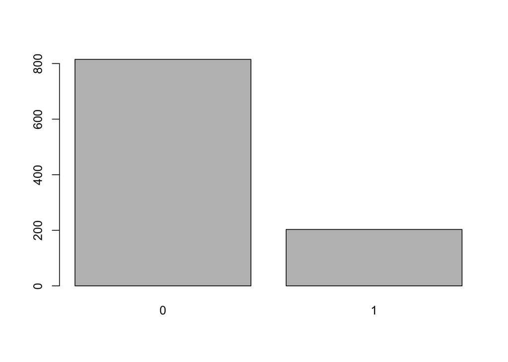

```r
table = table(Trait.1)
barplot(table)
```

We can see that for the DBP variable, we have 1397 datapoints with 379 missing values. 80% of the patients has DBP less than or equal to 80mmHg while 20% has it greater than 80mmHg. The mean and median of DBP are seperately 0.2 and 0 with a standard deviation of 0.4.

##### 2. Descriptive Statistics For Trait2: Average blood pressure

```r
skimr::skim(Trait.2)
```

Data summary

| Name | Trait.2 |
| --- | --- |
| Number of rows | 1397 |
| Number of columns | 1 |
| _______________________ |  |
| Column type frequency: |  |
| numeric | 1 |
| ________________________ |  |
| Group variables | None |

**Variable type: numeric**

| skim_variable | n_missing | complete_rate | mean | sd | p0 | p25 | p50 | p75 | p100 | hist |
| --- | --- | --- | --- | --- | --- | --- | --- | --- | --- | --- |
| data | 379 | 0.73 | 87.44 | 9.33 | 57 | 81 | 89 | 93 | 121 | ▁▃▇▂▁ |

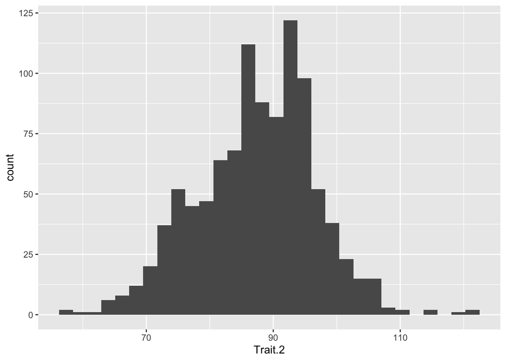

```r
df = as.data.frame(Trait.2)
ggplot(df, aes(x=Trait.2))+
  geom_histogram()
```

For the average blood pressure variable, we also have 1397 datapoints with 379 missing values. The data approximately follows a normal distribution, slightly left skewed with a mean of 87.44, median of 89 and standart deviation of 9.33.

##### 3. Association Analysis and Multiple Comparison Adjustment:

In the association analysis, no significant association was displayed between the traits and genes, indicating that we should analyze on more traits and genes.

##### 4. Population Stratification:

The PCA result showed that 93.47% of variance was explained by PC1 and 2.21% was explained by PC2. The scree plot also showed that we only need 2 dimensions to explain the data. This indicates that individuals with the same PC1 and PC2 values are likely to come from the same subpopulation, further association analysis could be done by conditioning on PC1 and PC2.